# GIS Layer Demonstration

```r
library(tidyverse)
library(sf)
library(here)
library(knitr)

theme_set(theme_bw() + theme(legend.position = "right", legend.direction = "vertical"))

gpkg_file <- here::here("outputs", "gis", "MI_OPW_tidal_analysis_v2.gpkg")

if (!file.exists(gpkg_file)) {
  stop(paste0("GeoPackage not found at: ", gpkg_file, "\nRun the GIS export script first."))
}
```

# Introduction

This notebook demonstrates the GIS layers produced from the MI/OPW tidal analysis.

The GeoPackage contains station locations, station-level tidal-feature estimates, and separate spatio-temporal prediction layers for HAT, MHWS, MHWN, MSL, MLWN, MLWS and LAT.

The prediction layers contain posterior mean estimates, posterior standard deviations and 95% credible intervals for every prediction location and year.

# GeoPackage contents

```r
gpkg_layers <- st_layers(gpkg_file)
gpkg_layers
```

```
## Driver: GPKG
## Available layers:
##       layer_name geometry_type features fields
## 1       stations         Point       36      3
## 2 tidal_features         Point      255     11
## 3       pred_HAT         Point  1829478      8
## 4       pred_LAT         Point  1829478      8
## 5      pred_MHWN         Point  1829478      8
## 6      pred_MHWS         Point  1829478      8
## 7      pred_MLWN         Point  1829478      8
## 8      pred_MLWS         Point  1829478      8
## 9       pred_MSL         Point  1829478      8
##                               crs_name
## 1 IRENET95 / Irish Transverse Mercator
## 2 IRENET95 / Irish Transverse Mercator
## 3 IRENET95 / Irish Transverse Mercator
## 4 IRENET95 / Irish Transverse Mercator
## 5 IRENET95 / Irish Transverse Mercator
## 6 IRENET95 / Irish Transverse Mercator
## 7 IRENET95 / Irish Transverse Mercator
## 8 IRENET95 / Irish Transverse Mercator
## 9 IRENET95 / Irish Transverse Mercator
```

# Station locations

The `stations` layer contains one point for each tide-gauge station included in the analysis. It does not contain any tidal feature estimates, simply the location of tide-gauge stations.

```r
stations <- st_read(gpkg_file, layer = "stations", quiet = TRUE)

stations
```

```
## Simple feature collection with 36 features and 3 fields
## Geometry type: POINT
## Dimension:     XY
## Bounding box:  xmin: 444122.1 ymin: 534654.5 xmax: 728497.1 ymax: 958508.8
## Projected CRS: IRENET95 / Irish Transverse Mercator
## First 10 features:
##                        st_id  Easting Northing                      geom
## 1                AdelphiQuay 661274.2 612375.1 POINT (661274.2 612375.1)
## 2  AranmoreIsland-Leabgarrow 568275.9 915904.8 POINT (568275.9 915904.8)
## 3         BallycottonHarbour 599951.7 563951.2 POINT (599951.7 563951.2)
## 4          BallyglassHarbour 476663.1 835516.3 POINT (476663.1 835516.3)
## 5                Carlingford 718377.7 812993.6 POINT (718377.7 812993.6)
## 6            CarrigaholtPier 484926.0 651302.9   POINT (484926 651302.9)
## 7         CastletownberePort 468289.4 545843.8 POINT (468289.4 545843.8)
## 8                CurrachClub 569456.6 572249.5 POINT (569456.6 572249.5)
## 9              DingleHarbour 444122.1 601044.3 POINT (444122.1 601044.3)
## 10                DublinPort 718407.6 734304.8 POINT (718407.6 734304.8)
```

## Station map

Plotting the station points alone produces the following map.

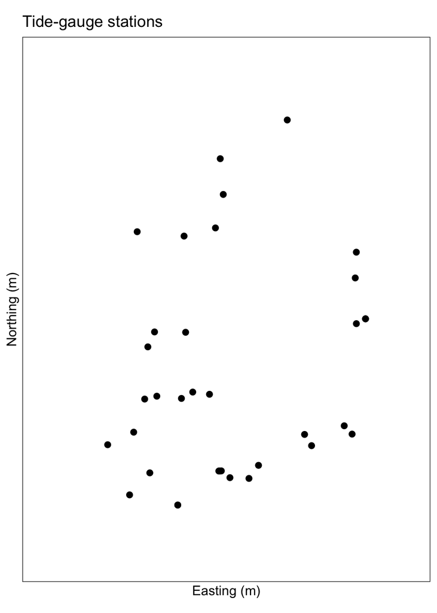

```r
stations |>
  ggplot() +
  geom_sf(size = 2) +
  coord_sf(crs = st_crs(2157), xlim = c(350000, 800000), ylim = c(450000, 1050000), expand = FALSE, datum = NA) +
  labs(title = "Tide-gauge stations", x = "Easting (m)", y = "Northing (m)")
```

Superimposing the points onto a shapefile of Ireland produces the following map.

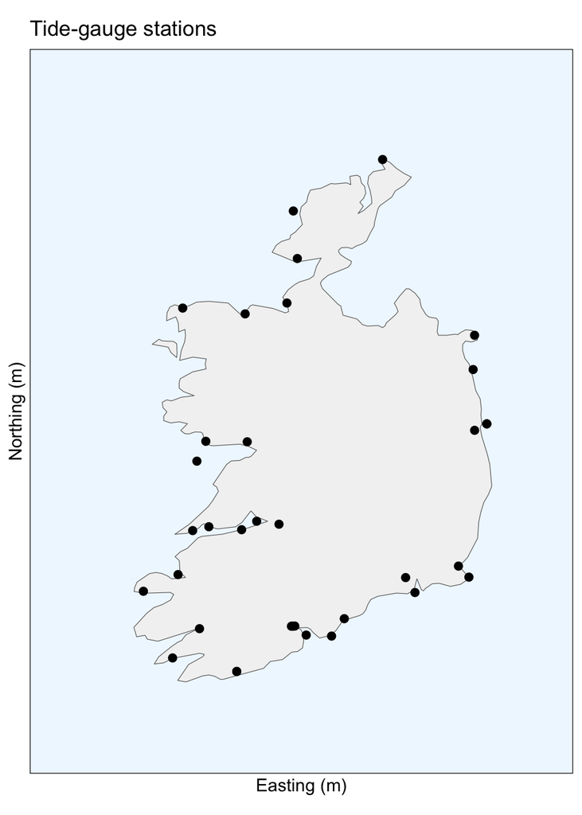

```r
## Ireland shapefile
ireland <- rnaturalearth::ne_countries(scale = "medium", country = "Ireland", returnclass = "sf")

## Plot stations over Ireland
ggplot() +
  geom_sf(data = ireland, fill = "grey95", colour = "grey40") +
  geom_sf(data = stations, size = 2) +
  coord_sf(crs = st_crs(2157), xlim = c(350000, 800000), ylim = c(450000, 1050000), expand = FALSE, datum = NA) +  labs(title = "Tide-gauge stations", x = "Easting (m)", y = "Northing (m)") +
  theme_bw() +
  theme(panel.background = element_rect(fill = "aliceblue", colour = NA))
```

# Station-level tidal features

The `tidal_features` layer contains the tidal characteristics calculated at the tide-gauge stations using the rolling-window harmonic analysis.

Each row represents one station and one midpoint year. HAT, MHWS, MHWN, MSL, MLWN, MLWS and LAT are stored as separate fields.

```r
tidal_features <- st_read(gpkg_file, layer = "tidal_features", quiet = TRUE)

tidal_features |>
  st_drop_geometry() |>
  arrange(StationID, Year) |>
  slice_head(n = 20) |>
  kable(digits = 3)
```

| StationID | Year | HAT | LAT | MHWN | MHWS | MLWN | MLWS | MSL | Easting | Northing |
| --- | --- | --- | --- | --- | --- | --- | --- | --- | --- | --- |
| AdelphiQuay | 2001 | 2.376 | -2.526 | 0.940 | 1.890 | -1.028 | -1.978 | -0.044 | 661274.2 | 612375.1 |
| AdelphiQuay | 2002 | 2.344 | -2.503 | 0.926 | 1.890 | -1.027 | -1.991 | -0.050 | 661274.2 | 612375.1 |
| AdelphiQuay | 2003 | 2.361 | -2.509 | 0.935 | 1.900 | -1.032 | -1.998 | -0.049 | 661274.2 | 612375.1 |
| AdelphiQuay | 2004 | 2.387 | -2.601 | 0.915 | 1.887 | -1.063 | -2.036 | -0.074 | 661274.2 | 612375.1 |
| AdelphiQuay | 2005 | 2.470 | -2.644 | 0.936 | 1.910 | -1.056 | -2.030 | -0.060 | 661274.2 | 612375.1 |
| AdelphiQuay | 2006 | 2.397 | -2.634 | 0.936 | 1.923 | -1.058 | -2.045 | -0.061 | 661274.2 | 612375.1 |
| AdelphiQuay | 2007 | 2.372 | -2.586 | 0.950 | 1.940 | -1.040 | -2.030 | -0.045 | 661274.2 | 612375.1 |
| AdelphiQuay | 2008 | 2.353 | -2.620 | 0.955 | 1.943 | -1.038 | -2.026 | -0.042 | 661274.2 | 612375.1 |
| AdelphiQuay | 2009 | 2.365 | -2.568 | 0.940 | 1.916 | -1.018 | -1.993 | -0.039 | 661274.2 | 612375.1 |
| AdelphiQuay | 2010 | 2.317 | -2.556 | 0.926 | 1.882 | -1.025 | -1.981 | -0.050 | 661274.2 | 612375.1 |
| AdelphiQuay | 2011 | 2.335 | -2.574 | 0.910 | 1.856 | -1.032 | -1.979 | -0.061 | 661274.2 | 612375.1 |
| AdelphiQuay | 2012 | 2.306 | -2.612 | 0.924 | 1.869 | -1.043 | -1.988 | -0.060 | 661274.2 | 612375.1 |
| AdelphiQuay | 2013 | 2.349 | -2.557 | 0.950 | 1.907 | -1.018 | -1.976 | -0.034 | 661274.2 | 612375.1 |
| AdelphiQuay | 2014 | 2.329 | -2.562 | 0.953 | 1.908 | -1.024 | -1.979 | -0.036 | 661274.2 | 612375.1 |
| AdelphiQuay | 2015 | 2.358 | -2.549 | 0.951 | 1.903 | -1.031 | -1.983 | -0.040 | 661274.2 | 612375.1 |
| AdelphiQuay | 2016 | 2.260 | -2.594 | 0.904 | 1.850 | -1.085 | -2.031 | -0.090 | 661274.2 | 612375.1 |
| AdelphiQuay | 2017 | 2.300 | -2.600 | 0.893 | 1.844 | -1.101 | -2.052 | -0.104 | 661274.2 | 612375.1 |
| AdelphiQuay | 2018 | 2.281 | -2.500 | 0.898 | 1.820 | -1.061 | -1.983 | -0.082 | 661274.2 | 612375.1 |
| AdelphiQuay | 2019 | 2.351 | -2.457 | 0.946 | 1.873 | -1.030 | -1.958 | -0.042 | 661274.2 | 612375.1 |
| AdelphiQuay | 2020 | 2.396 | -2.443 | 0.965 | 1.900 | -1.018 | -1.953 | -0.026 | 661274.2 | 612375.1 |

## Available years

Below we check the range of the temporal data provided in the `tidal_features` layer.

```r
tidal_features |>
  st_drop_geometry() |>
  summarise(first_year = min(Year, na.rm = TRUE), last_year = max(Year, na.rm = TRUE), n_years = n_distinct(Year)) |>
  kable()
```

| first_year | last_year | n_years |
| --- | --- | --- |
| 2001 | 2023 | 23 |

## Example station-level tidal-feature map

Below we choose the Mean High Water Springs tidal feature, along with the final year of the analysis, and we can plot this feature at each tide gauge station.

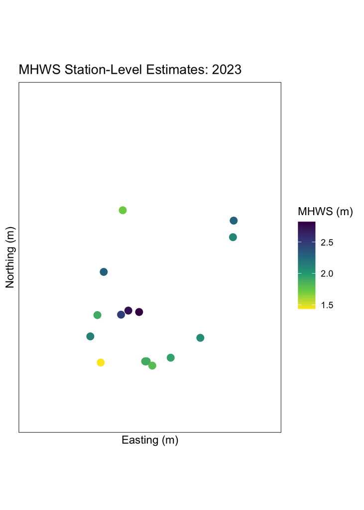

```r
station_feature <- "MHWS"

station_year <- tidal_features |>
  st_drop_geometry() |>
  filter(!is.na(.data[[station_feature]])) |>
  summarise(year = max(Year, na.rm = TRUE)) |>
  pull(year)

tidal_features |>
  filter(Year == station_year, !is.na(.data[[station_feature]])) |>
  ggplot() +
  geom_sf(aes(colour = .data[[station_feature]]), size = 3) +
  scale_colour_viridis_c(direction = -1) +
  coord_sf(crs = st_crs(2157), xlim = c(350000, 800000), ylim = c(450000, 1050000), expand = FALSE, datum = NA) +  labs(title = paste(station_feature, "Station-Level Estimates:", station_year), x = "Easting (m)", y = "Northing (m)", colour = paste0(station_feature, " (m)"))
```

## Tidal features through time at one station

We can also extract and plot tidal features through time. Below we choose Adelphi Quay, and examine all tidal features associated with this station.

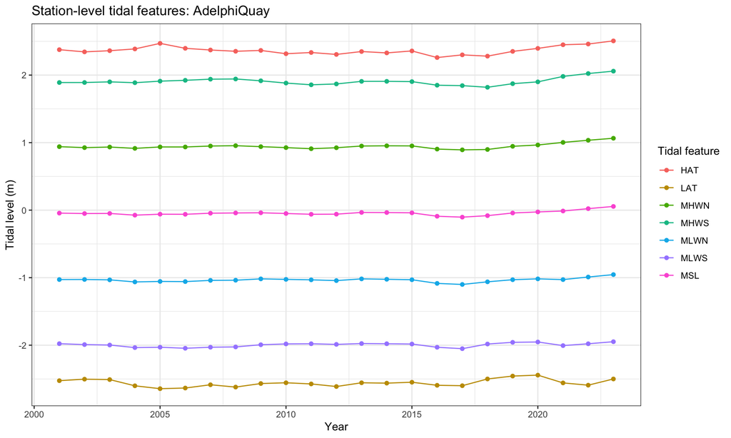

```r
example_station <- tidal_features |>
  st_drop_geometry() |>
  count(StationID, sort = TRUE) |>
  slice_head(n = 1) |>
  pull(StationID)


tidal_features |>
  st_drop_geometry() |>
  filter(StationID == example_station) |>
  select(Year, HAT, MHWS, MHWN, MSL, MLWN, MLWS, LAT) |>
  pivot_longer(-Year, names_to = "Tidal_feature", values_to = "Value") |>
  filter(!is.na(Value)) |>
  ggplot(aes(x = Year, y = Value, colour = Tidal_feature)) +
  geom_line() +
  geom_point() +
  labs(title = paste("Station-level tidal features:", example_station), x = "Year", y = "Tidal level (m)", colour = "Tidal feature")
```

# Spatio-temporal prediction layers

The GeoPackage contains a prediction layer for each tidal feature. The names of each layer are:

```r
prediction_layer_names <- paste0("pred_", c("HAT", "MHWS", "MHWN", "MSL", "MLWN", "MLWS", "LAT"))

prediction_layer_names
```

```
## [1] "pred_HAT"  "pred_MHWS" "pred_MHWN" "pred_MSL"  "pred_MLWN" "pred_MLWS"
## [7] "pred_LAT"
```

Note: Each prediction layer is large, so in this notebook we read only the layer currently being used and remove it from memory afterwards.

## HAT Predictions

In this section we read in the `pred_HAT` layer, examine it in tabular form and create maps to examine both the mean predicted HAT over the study area and the associated standard deviation.

```r
# Read in HAT prediction layer
pred_HAT <- st_read(gpkg_file, layer = "pred_HAT", quiet = TRUE)

# Examine its structure
pred_HAT |>
  st_drop_geometry() |>
  slice_head(n = 10) |>
  kable(digits = 3)
```

| year_idx | year_mid | Easting | Northing | mean | sd | q025 | q975 |
| --- | --- | --- | --- | --- | --- | --- | --- |
| 1 | 1991 | 378424.6 | 476816.9 | 2.302 | 11.192 | -19.633 | 24.238 |
| 1 | 1991 | 380413.6 | 476952.5 | 2.302 | 11.366 | -19.975 | 24.580 |
| 1 | 1991 | 382402.7 | 477088.2 | 2.302 | 14.114 | -25.360 | 29.965 |
| 1 | 1991 | 384391.8 | 477223.9 | 2.302 | 12.782 | -22.749 | 27.354 |
| 1 | 1991 | 386380.9 | 477359.5 | 2.302 | 10.691 | -18.652 | 23.257 |
| 1 | 1991 | 388370.1 | 477495.2 | 2.302 | 11.340 | -19.923 | 24.527 |
| 1 | 1991 | 418347.3 | 477540.7 | 2.302 | 11.266 | -19.779 | 24.384 |
| 1 | 1991 | 390359.2 | 477630.9 | 2.302 | 14.360 | -25.844 | 30.448 |
| 1 | 1991 | 420337.0 | 477676.3 | 2.302 | 13.689 | -24.528 | 29.132 |
| 1 | 1991 | 392348.5 | 477766.5 | 2.302 | 12.299 | -21.802 | 26.407 |

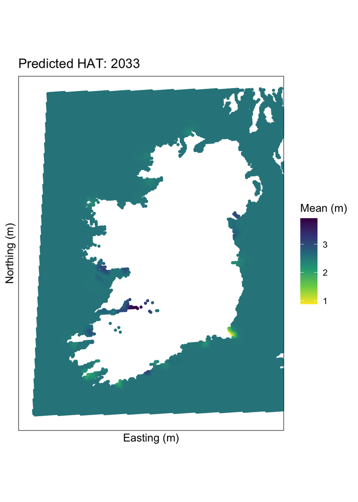

```r
# Choose a year to create a map
hat_year <- max(pred_HAT$year_mid, na.rm = TRUE) # final year of predictions

# Create a map of predictions for the mean HAT
pred_HAT |>
  filter(year_mid == hat_year) |>
  ggplot() +
  geom_sf(aes(colour = mean), size = 0.8) +
  scale_colour_viridis_c(direction = -1) +
  coord_sf(crs = st_crs(2157), xlim = c(350000, 800000), ylim = c(450000, 1050000), expand = FALSE, datum = NA) +  labs(title = paste("Predicted HAT:", hat_year), x = "Easting (m)", y = "Northing (m)", colour = "Mean (m)")
```

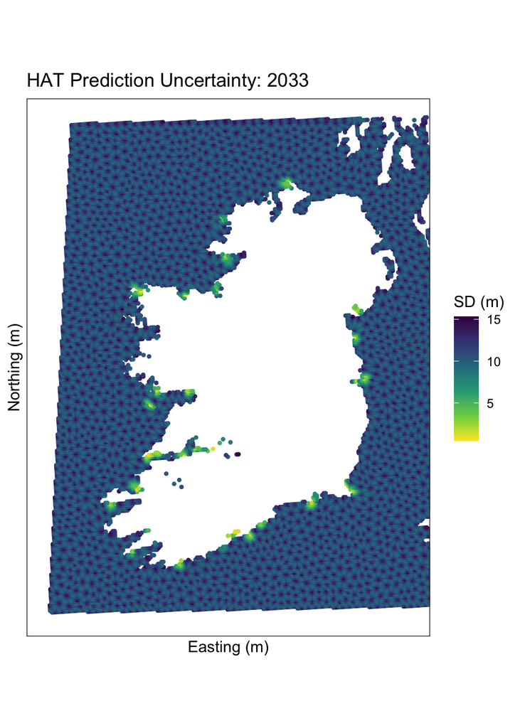

```r
# Create a map of predictions for the HAT standard deviation
pred_HAT |>
  filter(year_mid == hat_year) |>
  ggplot() +
  geom_sf(aes(colour = sd), size = 0.8) +
  coord_sf(crs = st_crs(2157), xlim = c(350000, 800000), ylim = c(450000, 1050000), expand = FALSE, datum = NA) +  scale_colour_viridis_c(direction = -1) +
  labs(title = paste("HAT Prediction Uncertainty:", hat_year), x = "Easting (m)", y = "Northing (m)", colour = "SD (m)")
```

```r
# cleanup HAT layer
rm(pred_HAT)
```

## MHWS Predictions

In this section we read in the `pred_MHWS` layer, examine it in tabular form and create maps to examine both the mean predicted MHWS over the study area and the associated standard deviation.

```r
# Read in MHWS prediction layer
pred_MHWS <- st_read(gpkg_file, layer = "pred_MHWS", quiet = TRUE)

# Examine its structure
pred_MHWS |>
  st_drop_geometry() |>
  slice_head(n = 10) |>
  kable(digits = 3)
```

| year_idx | year_mid | Easting | Northing | mean | sd | q025 | q975 |
| --- | --- | --- | --- | --- | --- | --- | --- |
| 1 | 1991 | 378424.6 | 476816.9 | 1.685 | 11.189 | -20.244 | 23.614 |
| 1 | 1991 | 380413.6 | 476952.5 | 1.685 | 11.363 | -20.586 | 23.956 |
| 1 | 1991 | 382402.7 | 477088.2 | 1.685 | 14.111 | -25.972 | 29.342 |
| 1 | 1991 | 384391.8 | 477223.9 | 1.685 | 12.778 | -23.360 | 26.730 |
| 1 | 1991 | 386380.9 | 477359.5 | 1.685 | 10.688 | -19.262 | 22.632 |
| 1 | 1991 | 388370.1 | 477495.2 | 1.685 | 11.336 | -20.533 | 23.903 |
| 1 | 1991 | 418347.3 | 477540.7 | 1.685 | 11.263 | -20.390 | 23.759 |
| 1 | 1991 | 390359.2 | 477630.9 | 1.685 | 14.357 | -26.454 | 29.824 |
| 1 | 1991 | 420337.0 | 477676.3 | 1.685 | 13.686 | -25.139 | 28.509 |
| 1 | 1991 | 392348.5 | 477766.5 | 1.685 | 12.295 | -22.413 | 25.782 |

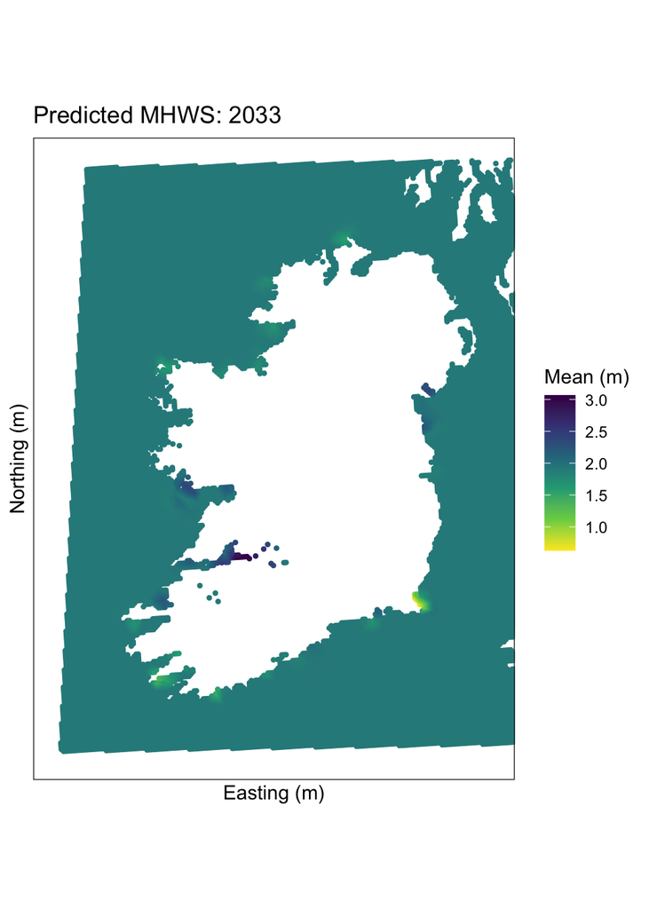

```r
# Choose a year to create a map
mhws_year <- max(pred_MHWS$year_mid, na.rm = TRUE) # final year of predictions

# Create a map of predictions for the mean MHWS
pred_MHWS |>
  filter(year_mid == mhws_year) |>
  ggplot() +
  geom_sf(aes(colour = mean), size = 0.8) +
  scale_colour_viridis_c(direction = -1) +
  coord_sf(crs = st_crs(2157), xlim = c(350000, 800000), ylim = c(450000, 1050000), expand = FALSE, datum = NA) +  labs(title = paste("Predicted MHWS:", mhws_year), x = "Easting (m)", y = "Northing (m)", colour = "Mean (m)")
```

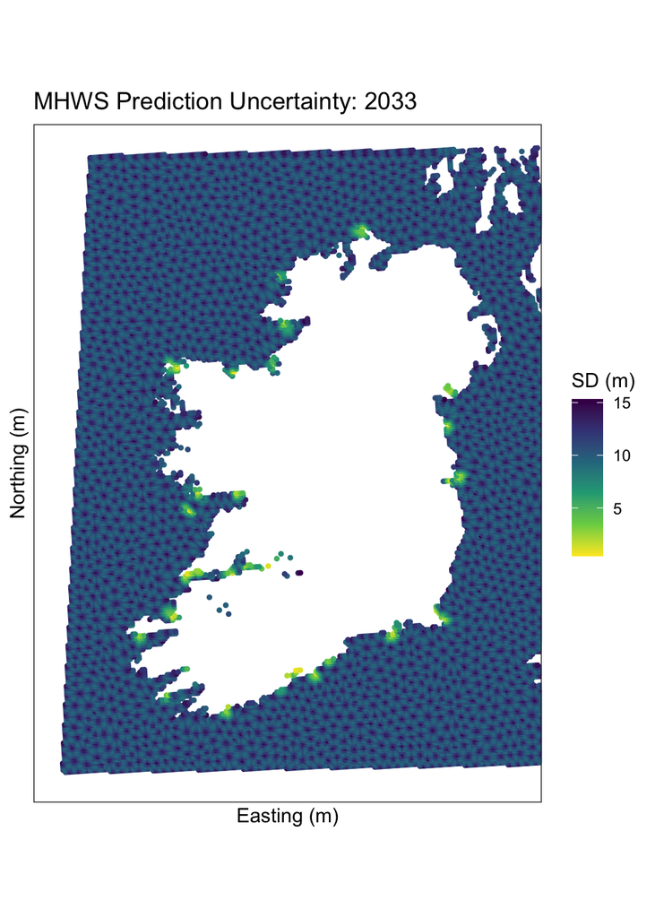

```r
# Create a map of predictions for the MHWS standard deviation
pred_MHWS |>
  filter(year_mid == mhws_year) |>
  ggplot() +
  geom_sf(aes(colour = sd), size = 0.8) +
  coord_sf(crs = st_crs(2157), xlim = c(350000, 800000), ylim = c(450000, 1050000), expand = FALSE, datum = NA) +  scale_colour_viridis_c(direction = -1) +
  labs(title = paste("MHWS Prediction Uncertainty:", mhws_year), x = "Easting (m)", y = "Northing (m)", colour = "SD (m)")
```

```r
# cleanup MHWS layer
rm(pred_MHWS)
```

## MHWN predictions

In this section we read in the `pred_MHWN` layer, examine it in tabular form and create maps to examine both the mean predicted MHWN over the study area and the associated standard deviation.

```r
# Read in MHWN prediction layer
pred_MHWN <- st_read(gpkg_file, layer = "pred_MHWN", quiet = TRUE)

# Examine its structure
pred_MHWN |>
  st_drop_geometry() |>
  slice_head(n = 10) |>
  kable(digits = 3)
```

| year_idx | year_mid | Easting | Northing | mean | sd | q025 | q975 |
| --- | --- | --- | --- | --- | --- | --- | --- |
| 1 | 1991 | 378424.6 | 476816.9 | 0.832 | 0.407 | 0.034 | 1.630 |
| 1 | 1991 | 380413.6 | 476952.5 | 0.832 | 0.418 | 0.013 | 1.652 |
| 1 | 1991 | 382402.7 | 477088.2 | 0.833 | 0.436 | -0.022 | 1.687 |
| 1 | 1991 | 384391.8 | 477223.9 | 0.833 | 0.430 | -0.010 | 1.676 |
| 1 | 1991 | 386380.9 | 477359.5 | 0.833 | 0.422 | 0.007 | 1.659 |
| 1 | 1991 | 388370.1 | 477495.2 | 0.833 | 0.423 | 0.004 | 1.662 |
| 1 | 1991 | 418347.3 | 477540.7 | 0.823 | 0.387 | 0.065 | 1.581 |
| 1 | 1991 | 390359.2 | 477630.9 | 0.833 | 0.434 | -0.018 | 1.684 |
| 1 | 1991 | 420337.0 | 477676.3 | 0.822 | 0.391 | 0.056 | 1.587 |
| 1 | 1991 | 392348.5 | 477766.5 | 0.833 | 0.420 | 0.009 | 1.656 |

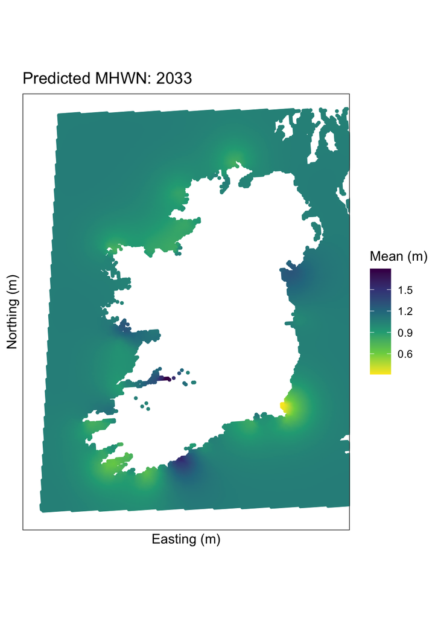

```r
# Choose a year to create a map
mhwn_year <- max(pred_MHWN$year_mid, na.rm = TRUE) # final year of predictions

# Create a map of predictions for the mean MHWN
pred_MHWN |>
  filter(year_mid == mhwn_year) |>
  ggplot() +
  geom_sf(aes(colour = mean), size = 0.8) +
  scale_colour_viridis_c(direction = -1) +
  coord_sf(crs = st_crs(2157), xlim = c(350000, 800000), ylim = c(450000, 1050000), expand = FALSE, datum = NA) +  labs(title = paste("Predicted MHWN:", mhwn_year), x = "Easting (m)", y = "Northing (m)", colour = "Mean (m)")
```

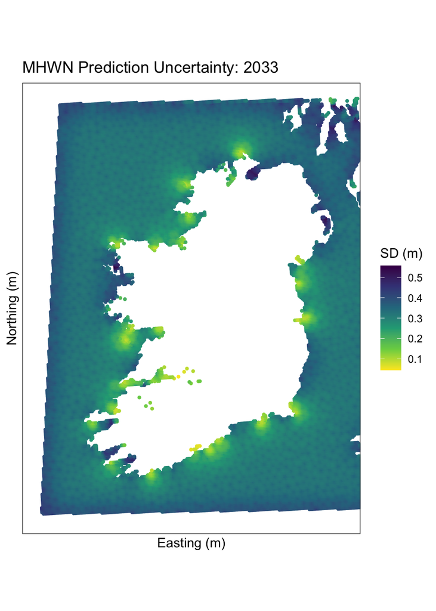

```r
# Create a map of predictions for the MHWN standard deviation
pred_MHWN |>
  filter(year_mid == mhwn_year) |>
  ggplot() +
  geom_sf(aes(colour = sd), size = 0.8) +
  coord_sf(crs = st_crs(2157), xlim = c(350000, 800000), ylim = c(450000, 1050000), expand = FALSE, datum = NA) +  scale_colour_viridis_c(direction = -1) +
  labs(title = paste("MHWN Prediction Uncertainty:", mhwn_year), x = "Easting (m)", y = "Northing (m)", colour = "SD (m)")
```

```r
# cleanup MHWN layer
rm(pred_MHWN)
```

## MSL predictions

In this section we read in the `pred_MSL` layer, examine it in tabular form and create maps to examine both the mean predicted MSL over the study area and the associated standard deviation.

```r
# Read in MSL prediction layer
pred_MSL <- st_read(gpkg_file, layer = "pred_MSL", quiet = TRUE)

# Examine its structure
pred_MSL |>
  st_drop_geometry() |>
  slice_head(n = 10) |>
  kable(digits = 3)
```

| year_idx | year_mid | Easting | Northing | mean | sd | q025 | q975 |
| --- | --- | --- | --- | --- | --- | --- | --- |
| 1 | 1991 | 378424.6 | 476816.9 | -0.147 | 0.215 | -0.568 | 0.275 |
| 1 | 1991 | 380413.6 | 476952.5 | -0.147 | 0.222 | -0.583 | 0.289 |
| 1 | 1991 | 382402.7 | 477088.2 | -0.147 | 0.235 | -0.607 | 0.313 |
| 1 | 1991 | 384391.8 | 477223.9 | -0.147 | 0.231 | -0.601 | 0.306 |
| 1 | 1991 | 386380.9 | 477359.5 | -0.148 | 0.226 | -0.591 | 0.296 |
| 1 | 1991 | 388370.1 | 477495.2 | -0.148 | 0.228 | -0.595 | 0.300 |
| 1 | 1991 | 418347.3 | 477540.7 | -0.151 | 0.212 | -0.567 | 0.265 |
| 1 | 1991 | 390359.2 | 477630.9 | -0.148 | 0.237 | -0.613 | 0.317 |
| 1 | 1991 | 420337.0 | 477676.3 | -0.151 | 0.215 | -0.572 | 0.270 |
| 1 | 1991 | 392348.5 | 477766.5 | -0.148 | 0.228 | -0.596 | 0.300 |

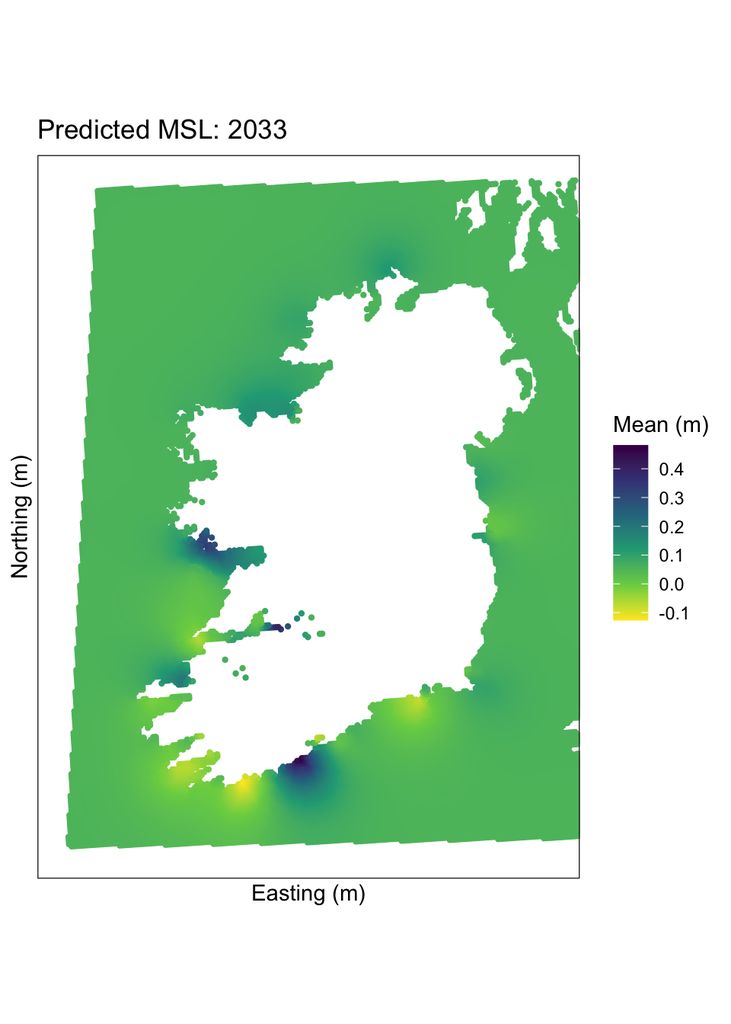

```r
# Choose a year to create a map
msl_year <- max(pred_MSL$year_mid, na.rm = TRUE) # final year of predictions

# Create a map of predictions for the mean MSL
pred_MSL |>
  filter(year_mid == msl_year) |>
  ggplot() +
  geom_sf(aes(colour = mean), size = 0.8) +
  scale_colour_viridis_c(direction = -1) +
  coord_sf(crs = st_crs(2157), xlim = c(350000, 800000), ylim = c(450000, 1050000), expand = FALSE, datum = NA) +  labs(title = paste("Predicted MSL:", msl_year), x = "Easting (m)", y = "Northing (m)", colour = "Mean (m)")
```

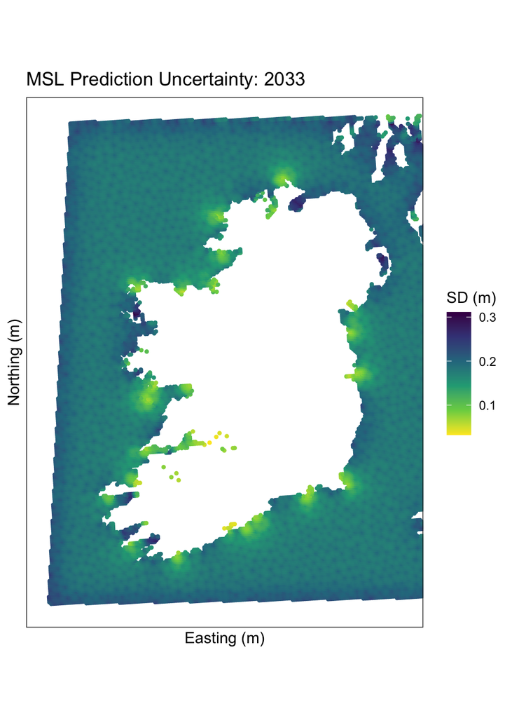

```r
# Create a map of predictions for the MSL standard deviation
pred_MSL |>
  filter(year_mid == msl_year) |>
  ggplot() +
  geom_sf(aes(colour = sd), size = 0.8) +
  coord_sf(crs = st_crs(2157), xlim = c(350000, 800000), ylim = c(450000, 1050000), expand = FALSE, datum = NA) +  scale_colour_viridis_c(direction = -1) +
  labs(title = paste("MSL Prediction Uncertainty:", msl_year), x = "Easting (m)", y = "Northing (m)", colour = "SD (m)")
```

```r
# cleanup MSL layer
rm(pred_MSL)
```

## MLWN predictions

In this section we read in the `pred_MLWN` layer, examine it in tabular form and create maps to examine both the mean predicted MLWN over the study area and the associated standard deviation.

```r
# Read in MLWN prediction layer
pred_MLWN <- st_read(gpkg_file, layer = "pred_MLWN", quiet = TRUE)

# Examine its structure
pred_MLWN |>
  st_drop_geometry() |>
  slice_head(n = 10) |>
  kable(digits = 3)
```

| year_idx | year_mid | Easting | Northing | mean | sd | q025 | q975 |
| --- | --- | --- | --- | --- | --- | --- | --- |
| 1 | 1991 | 378424.6 | 476816.9 | -1.120 | 0.331 | -1.768 | -0.472 |
| 1 | 1991 | 380413.6 | 476952.5 | -1.121 | 0.342 | -1.792 | -0.450 |
| 1 | 1991 | 382402.7 | 477088.2 | -1.122 | 0.362 | -1.831 | -0.413 |
| 1 | 1991 | 384391.8 | 477223.9 | -1.123 | 0.356 | -1.821 | -0.425 |
| 1 | 1991 | 386380.9 | 477359.5 | -1.124 | 0.348 | -1.807 | -0.441 |
| 1 | 1991 | 388370.1 | 477495.2 | -1.124 | 0.352 | -1.814 | -0.435 |
| 1 | 1991 | 418347.3 | 477540.7 | -1.127 | 0.327 | -1.767 | -0.487 |
| 1 | 1991 | 390359.2 | 477630.9 | -1.125 | 0.366 | -1.842 | -0.409 |
| 1 | 1991 | 420337.0 | 477676.3 | -1.127 | 0.331 | -1.775 | -0.478 |
| 1 | 1991 | 392348.5 | 477766.5 | -1.125 | 0.352 | -1.815 | -0.436 |

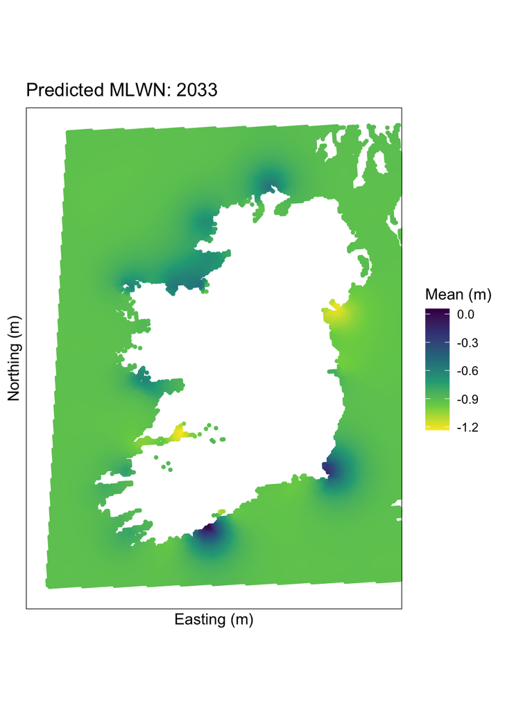

```r
# Choose a year to create a map
mlwn_year <- max(pred_MLWN$year_mid, na.rm = TRUE) # final year of predictions

# Create a map of predictions for the mean MLWN
pred_MLWN |>
  filter(year_mid == mlwn_year) |>
  ggplot() +
  geom_sf(aes(colour = mean), size = 0.8) +
  scale_colour_viridis_c(direction = -1) +
  coord_sf(crs = st_crs(2157), xlim = c(350000, 800000), ylim = c(450000, 1050000), expand = FALSE, datum = NA) +  labs(title = paste("Predicted MLWN:", mlwn_year), x = "Easting (m)", y = "Northing (m)", colour = "Mean (m)")
```

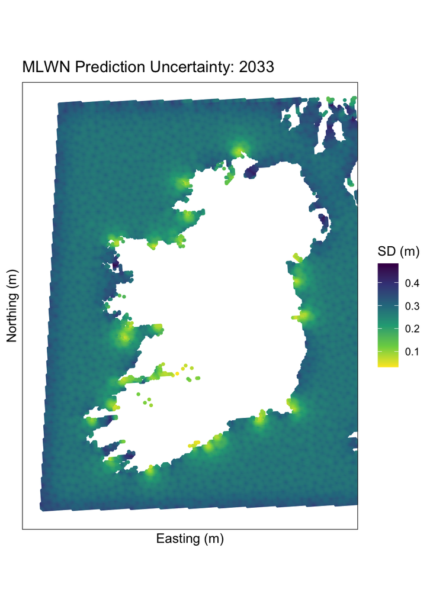

```r
# Create a map of predictions for the MLWN standard deviation
pred_MLWN |>
  filter(year_mid == mlwn_year) |>
  ggplot() +
  geom_sf(aes(colour = sd), size = 0.8) +
  coord_sf(crs = st_crs(2157), xlim = c(350000, 800000), ylim = c(450000, 1050000), expand = FALSE, datum = NA) +  scale_colour_viridis_c(direction = -1) +
  labs(title = paste("MLWN Prediction Uncertainty:", mlwn_year), x = "Easting (m)", y = "Northing (m)", colour = "SD (m)")
```

```r
# cleanup MLWN layer
rm(pred_MLWN)
```

## MLWS predictions

In this section we read in the `pred_MLWS` layer, examine it in tabular form and create maps to examine both the mean predicted MLWS over the study area and the associated standard deviation.

```r
# Read in MLWS prediction layer
pred_MLWS <- st_read(gpkg_file, layer = "pred_MLWS", quiet = TRUE)

# Examine its structure
pred_MLWS |>
  st_drop_geometry() |>
  slice_head(n = 10) |>
  kable(digits = 3)
```

| year_idx | year_mid | Easting | Northing | mean | sd | q025 | q975 |
| --- | --- | --- | --- | --- | --- | --- | --- |
| 1 | 1991 | 378424.6 | 476816.9 | -2.051 | 0.503 | -3.037 | -1.066 |
| 1 | 1991 | 380413.6 | 476952.5 | -2.052 | 0.508 | -3.048 | -1.056 |
| 1 | 1991 | 382402.7 | 477088.2 | -2.053 | 0.516 | -3.064 | -1.041 |
| 1 | 1991 | 384391.8 | 477223.9 | -2.053 | 0.512 | -3.055 | -1.050 |
| 1 | 1991 | 386380.9 | 477359.5 | -2.052 | 0.505 | -3.043 | -1.062 |
| 1 | 1991 | 388370.1 | 477495.2 | -2.052 | 0.503 | -3.038 | -1.067 |
| 1 | 1991 | 418347.3 | 477540.7 | -2.028 | 0.435 | -2.880 | -1.176 |
| 1 | 1991 | 390359.2 | 477630.9 | -2.052 | 0.504 | -3.040 | -1.064 |
| 1 | 1991 | 420337.0 | 477676.3 | -2.026 | 0.434 | -2.876 | -1.175 |
| 1 | 1991 | 392348.5 | 477766.5 | -2.051 | 0.495 | -3.021 | -1.082 |

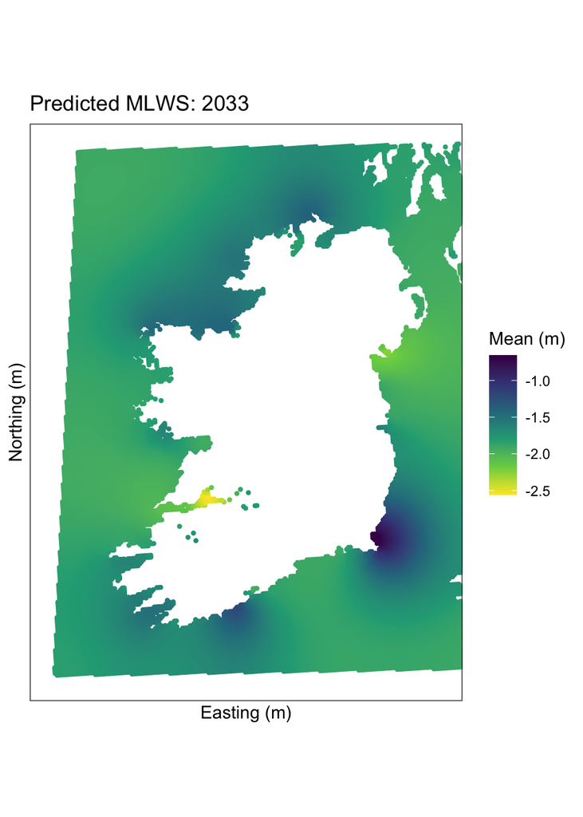

```r
# Choose a year to create a map
mlws_year <- max(pred_MLWS$year_mid, na.rm = TRUE) # final year of predictions

# Create a map of predictions for the mean MLWS
pred_MLWS |>
  filter(year_mid == mlws_year) |>
  ggplot() +
  geom_sf(aes(colour = mean), size = 0.8) +
  scale_colour_viridis_c(direction = -1) +
  coord_sf(crs = st_crs(2157), xlim = c(350000, 800000), ylim = c(450000, 1050000), expand = FALSE, datum = NA) +  labs(title = paste("Predicted MLWS:", mlws_year), x = "Easting (m)", y = "Northing (m)", colour = "Mean (m)")
```

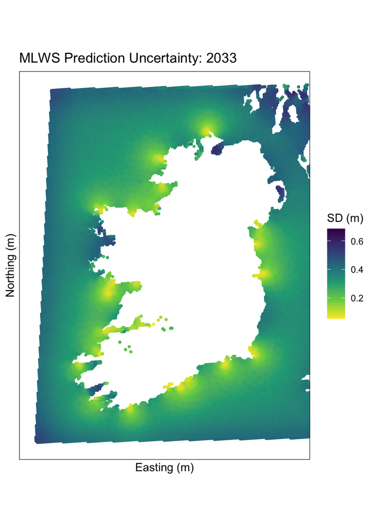

```r
# Create a map of predictions for the MLWS standard deviation
pred_MLWS |>
  filter(year_mid == mlws_year) |>
  ggplot() +
  geom_sf(aes(colour = sd), size = 0.8) +
  coord_sf(crs = st_crs(2157), xlim = c(350000, 800000), ylim = c(450000, 1050000), expand = FALSE, datum = NA) +  scale_colour_viridis_c(direction = -1) +
  labs(title = paste("MLWS Prediction Uncertainty:", mlws_year), x = "Easting (m)", y = "Northing (m)", colour = "SD (m)")
```

```r
# cleanup MLWS layer
rm(pred_MLWS)
```

## LAT predictions

In this section we read in the `pred_LAT` layer, examine it in tabular form and create maps to examine both the mean predicted LAT over the study area and the associated standard deviation.

```r
# Read in LAT prediction layer
pred_LAT <- st_read(gpkg_file, layer = "pred_LAT", quiet = TRUE)

# Examine its structure
pred_LAT |>
  st_drop_geometry() |>
  slice_head(n = 10) |>
  kable(digits = 3)
```

| year_idx | year_mid | Easting | Northing | mean | sd | q025 | q975 |
| --- | --- | --- | --- | --- | --- | --- | --- |
| 1 | 1991 | 378424.6 | 476816.9 | -2.519 | 11.790 | -25.627 | 20.588 |
| 1 | 1991 | 380413.6 | 476952.5 | -2.519 | 12.192 | -26.414 | 21.376 |
| 1 | 1991 | 382402.7 | 477088.2 | -2.519 | 15.154 | -32.220 | 27.181 |
| 1 | 1991 | 384391.8 | 477223.9 | -2.519 | 13.831 | -29.627 | 24.588 |
| 1 | 1991 | 386380.9 | 477359.5 | -2.519 | 11.819 | -25.684 | 20.646 |
| 1 | 1991 | 388370.1 | 477495.2 | -2.519 | 12.650 | -27.312 | 22.273 |
| 1 | 1991 | 418347.3 | 477540.7 | -2.519 | 12.307 | -26.641 | 21.602 |
| 1 | 1991 | 390359.2 | 477630.9 | -2.519 | 15.882 | -33.648 | 28.609 |
| 1 | 1991 | 420337.0 | 477676.3 | -2.519 | 14.606 | -31.146 | 26.107 |
| 1 | 1991 | 392348.5 | 477766.5 | -2.519 | 13.686 | -29.343 | 24.304 |

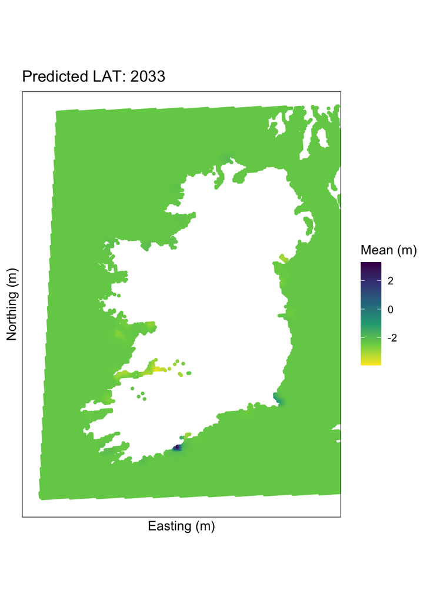

```r
# Choose a year to create a map
lat_year <- max(pred_LAT$year_mid, na.rm = TRUE) # final year of predictions

# Create a map of predictions for the mean LAT
pred_LAT |>
  filter(year_mid == lat_year) |>
  ggplot() +
  geom_sf(aes(colour = mean), size = 0.8) +
  scale_colour_viridis_c(direction = -1) +
  coord_sf(crs = st_crs(2157), xlim = c(350000, 800000), ylim = c(450000, 1050000), expand = FALSE, datum = NA) +  labs(title = paste("Predicted LAT:", lat_year), x = "Easting (m)", y = "Northing (m)", colour = "Mean (m)")
```

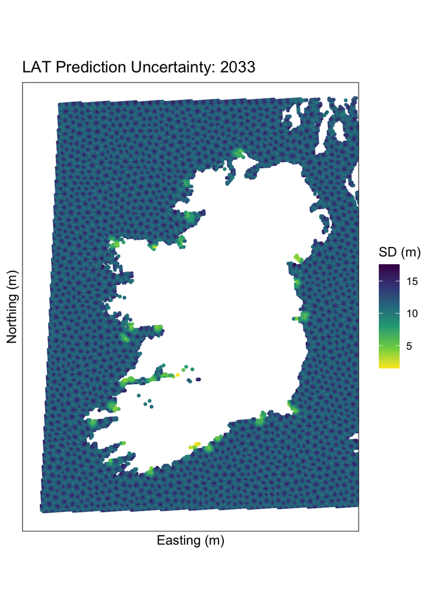

```r
# Create a map of predictions for the LAT standard deviation
pred_LAT |>
  filter(year_mid == lat_year) |>
  ggplot() +
  geom_sf(aes(colour = sd), size = 0.8) +
  coord_sf(crs = st_crs(2157), xlim = c(350000, 800000), ylim = c(450000, 1050000), expand = FALSE, datum = NA) +  scale_colour_viridis_c(direction = -1) +
  labs(title = paste("LAT Prediction Uncertainty:", lat_year), x = "Easting (m)", y = "Northing (m)", colour = "SD (m)")
```

```r
# cleanup LAT layer
rm(pred_LAT)
```

## Comparing prediction layers

The following summary compares the range of posterior mean predictions and uncertainty across the seven prediction layers.

```r
prediction_summary <- map_dfr(prediction_layer_names, \(layer_name) {
    x <- st_read(gpkg_file, layer = layer_name, quiet = TRUE)

    out <- x |>
      st_drop_geometry() |>
      summarise(
        first_year = min(year_mid, na.rm = TRUE),
        last_year = max(year_mid, na.rm = TRUE),
        n_rows = n(),
        mean_min = min(mean, na.rm = TRUE),
        mean_max = max(mean, na.rm = TRUE),
        sd_median = median(sd, na.rm = TRUE),
        sd_max = max(sd, na.rm = TRUE)) |>
      mutate(tidal_feature = str_remove(layer_name, "^pred_"), .before = 1)

    rm(x)
    gc(verbose = FALSE)

    out
  }
)

prediction_summary |>
  kable(digits = 3, format.args = list(big.mark = ","),
    col.names = c(
      "Tidal feature",
      "First year",
      "Last year",
      "Rows",
      "Minimum predicted mean",
      "Maximum predicted mean",
      "Median SD",
      "Maximum SD"))
```

| Tidal feature | First year | Last year | Rows | Minimum predicted mean | Maximum predicted mean | Median SD | Maximum SD |
| --- | --- | --- | --- | --- | --- | --- | --- |
| HAT | 1,991 | 2,033 | 1,829,478 | 0.674 | 3.917 | 10.646 | 15.323 |
| MHWS | 1,991 | 2,033 | 1,829,478 | 0.438 | 3.066 | 10.643 | 15.320 |
| MHWN | 1,991 | 2,033 | 1,829,478 | 0.044 | 1.793 | 0.326 | 0.558 |
| MSL | 1,991 | 2,033 | 1,829,478 | -0.327 | 0.482 | 0.182 | 0.313 |
| MLWN | 1,991 | 2,033 | 1,829,478 | -1.447 | 0.057 | 0.281 | 0.484 |
| MLWS | 1,991 | 2,033 | 1,829,478 | -2.755 | -0.657 | 0.352 | 0.687 |
| LAT | 1,991 | 2,033 | 1,829,478 | -4.096 | 3.356 | 11.269 | 17.615 |